# Onset Detection, La Corte Lorenzo

# Contesto

Un onset è la fase antecedente al picco di ampiezza di un segnale sonoro:

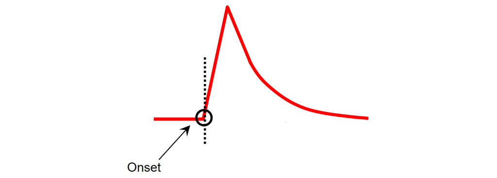

Nella pubblicazione scientifica *evaluating the online capabilities of onset detection methods* ci vengono illustrati molti metodi per la onset detection, che si dividono principalmente in:

- Sviluppo di una **Onset Detection Function (ODF)**: sviluppo di una curva che descriva il cambiamento di intensità sonora tra frame vicini,
- Identificazione dei picchi (**Peak-Peaking**) sulla ODF.

Tutti i moderni algoritmi di onset detection usano una rappresentazione del segnale per frequenze, ottenuta grazie alla STFT, da cui poi si deriva lo spettrogramma; su di esso viene calcolato lo **spectral flux**, che risulta essere la tecnica di ODF piu' moderna ed efficace; sulla funzione ODF viene poi implementato il **peak-peaking**, ovvero l'identificazione dei picchi.

Provo quindi a costruire la mia *Onset Detection* basandomi su questi macroscopici step; nel dettaglio faccio riferimento alle formule dell'articolo, cercando di ottenere un risultato quanto piu' vicino possibile a quello reale.

# Obiettivi

- Creare un metodo di *onset detection*, diviso in:
  - costruzione dello *spectral flux*,
  - identificazione dei picchi.
- Confrontare i risultati rispetto a librosa, trovando le criticità dell'implementazione e quelle eventuali della libreria.

# Metodo Implementato

Importo una serie di librerie che verranno usate nell'implementazione del metodo e nella fase di analisi dei risultati:

```python
# librerie principali
import numpy as np
import matplotlib.pyplot as plt
import IPython
from statistics import mean
import warnings
import scipy
warnings.filterwarnings("ignore")
%matplotlib inline

# librosa
import librosa
import librosa.display

# Parametri Principali
DURATION = 20
hop_length = 512
```

### Calcolo dello *Spectral Flux*

Implemento una funzione che calcola lo *spectral flux* a partire dallo spettrogramma derivante dal segnale;

La funzione risultante sarà **indicativa di come cambiano le intensità dello spettro tra un frame temporale e quello precedente**.

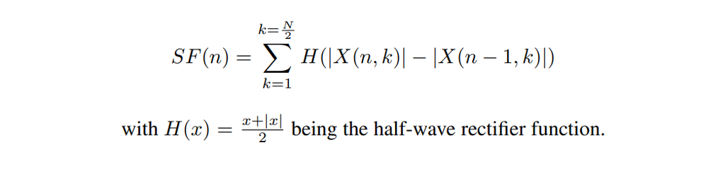

```python
def implemented_onset_strength(S, sr, hop_length):
    odf_sf = []

    # normalizzazione dello spectral flux
    norm = np.linalg.norm(S.ravel() , ord=2)

    # sommatoria sulle differenze di intensità tra frame vicini
    for n in range(0,S.shape[1]-1):
        sum = 0
        for k in range(0,S.shape[0]-1):
            sum += abs(S[k,n]) - abs(S[k,n-1])

        odf_sf.append(sum/norm)

    # Applico la half-wave rectifier function eliminando i negativi
    odf_sf = np.maximum(0.00, odf_sf)

    return odf_sf
```

### Identificazione dei Picchi sullo *Spectral Flux*

Sviluppo adesso una funzione che identifichi i picchi *spectral flux*, che essendo i punti di massimo cambiamento sono gli onset;

Identifichiamo con *n* il frame temporale e con *ODF(n)* il valore dello *spectral flax* in quel frame: *ODF(n)* è definito picco se ci sono tre condizioni:

- se *ODF(n) = **max**(ODF(n-w1:n+w2))*
- se *ODF(n) >= **mean**(ODF(n-w3:n+w4)) + delta*
- se *n > (**n_last_onset**) + w5*

con:

- *w1 (**pre_max**)*: quanti frame temporali antecedenti a quello corrente vengono considerati nel calcolo del massimo;
- *w2 (**post_max**)*: quanti frame temporali successivi a quello corrente vengono considerati nel calcolo del massimo;
- *delta (**threshold**)*: soglia che, sommata alla media in un dato intervallo di tempo, deve essere superata per la considerazione di un picco;
- *w3 (**pre_avg**)*: quanti frame temporali antecedenti a quello corrente vengono considerati nel calcolo della media;
- *w4 (**post_avg**)*: quanti frame temporali successivi a quello corrente vengono considerati nel calcolo della media;
- *w5 (**wait**)*: i minimi frame temporali che devono passare da un picco a quello successivo.

```python
def implemented_peak_pick(odf_sf, w1, w2, w3, w4, delta, w5):
    onsets = []
    n_last_onset = 0

    # scorro tutti i frame di ODF(n)
    for n, odf_value in enumerate(odf_sf):

        isPeak = True # se resta True allora è un picco

        # per evitare errori non considero frame che porterebbero a intervalli di tempo negativi
        if (n-w1) < 0 or (n-w3) < 0:
            isPeak = False
            continue

       # un odf_value ODF(n) è definito picco se ci sono tre condizioni:

        # 1. se ODF(n) = odf_value = max(ODF(n-w1:n+w2))
        if odf_value != max(odf_sf[n-w1:n+w2]):
                isPeak = False

        # 2. se ODF(n) = odf_value >= mean(ODF(n-w3:n+w4)) + delta
        if odf_value < (mean(odf_sf[n-w3:n+w4]) + delta):
                isPeak = False

        # 3. se n > (n_last_onset) + w5
        if(n < (n_last_onset + w5)):
            isPeak = False

        if isPeak:
            onsets.append(n)
            n_last_onset = n

    return onsets
```

### Funzione Principale

Definisco ora una funzione che racchiude i vari passi per l'identificazione degli onset, che quindi:

- Calcola lo spettrogramma,
- Calcola lo *spectral flux*,
- Identifica i picchi su di esso.

```python
def my_onset_detect(y, sr):

    if y is None:
        raise ParameterError("Assenza di un segnale in input.")

    # Parametri per il calcolo dello spettrogramma
    n_mels = 138
    fmin = 27.5
    fmax = 16000.

    global S
    S = librosa.feature.melspectrogram(y, sr=sr, hop_length=hop_length, fmin=fmin, fmax=fmax, n_mels=n_mels)

    # Onset Detection Function (ODF) basata sullo spectral flux
    global odf_sf
    odf_sf = implemented_onset_strength(S, sr, hop_length)

    # Peak-Peaking sullo spectral flux

    # pre_max: 3 valore ottimale secondo l'articolo, librosa gli da 1
    w1 = 3

    # post_max: 0-1 valori ottimali secondo l'articolo, librosa gli da 1
    w2 = 1

    # pre_avg: valore ottimale tra 4 e 12, librosa gli da 4
    w3 = 4

    # post_avg: 0-1 valori ottimali, librosa gli da 1
    w4 = 1

    # è la soglia di threshold, librosa gli da 0.07, impostata piu' bassa a causa di una diversa normalizzazione
    delta = 0.003

    # wait: 3 valore ottimale, librosa gli da 1
    w5 = 3

    onsets = implemented_peak_pick(odf_sf, w1, w2, w3, w4, delta, w5)

    return onsets
```

# Analisi ed Esperimenti

Eseguo adesso una serie di test sul metodo implementato; utilizzo come valori per il confronto quelli dati in output dalla libreria Librosa, anche se non è detto (come vedremo) che essa identifichi tutti e soli gli onset corretti. Analizzo in particolare tre caratteristiche del metodo implementato:

- la **precisione**:
  - quanto si discosta in termini di numero di onset,
  - quanto si discosta in termini di posizione precisa identificata per l'onset.
- la **scalabilità**: quanto peggiora o migliora l'implementazione all'aumentare della durata della traccia.
- l'**adattabilità**: quanto peggiora o migliora l'implementazione al variare della traccia.

### Risultati Generali

Per dare un primo sguardo generale ho creato un programma in python *(allegato alla consegna)* che esegue il programma su tutte le 13 tracce esistenti nella libreria librosa e su diverse durate per le tracce: da 10 a 120 secondi.

Trovo in questo modo:

- un media sulle tracce di quanto l'implementazione si discosta da librosa per quella determinata durata in secondi;
- un'indicazione di quale sia la traccia che si comporta meglio nel confronto con librosa;
- un'indicazione di quale sia la traccia che si comporta peggio nel confronto con librosa.

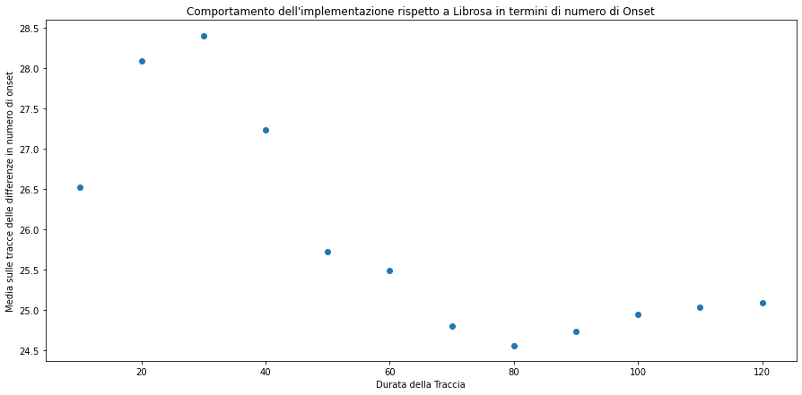

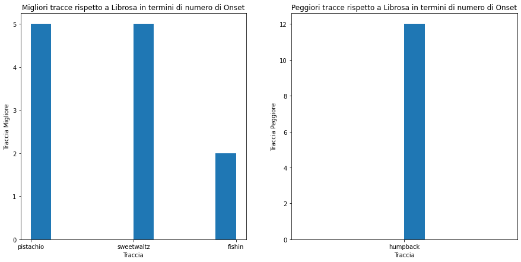

```python
durations_list = [10, 20, 30, 40, 50, 60, 70, 80, 90, 100, 110, 120]

# Lista delle medie generali sulle differenze in numero di onset rispetto a Librosa
list_avg = [26.519301204884357, 28.087228002943796, 28.40186818561876, 27.233590090786095, 25.72035111121484, 25.487858297329918, 24.79864331076603, 24.564567465626514, 24.735258659058033, 24.944857731289176, 25.03113697631367, 25.095662251406768]

plt.figure(figsize=(15,7))
plt.title("Comportamento dell'implementazione rispetto a Librosa in termini di numero di Onset")
plt.xlabel("Durata della Traccia")
plt.ylabel("Media sulle tracce delle differenze in numero di onset")
plt.scatter(durations_list, list_avg)
plt.show()

# Lista delle migliori traccie sul numero di onset rispetto a Librosa
best_tracks = ['pistachio', 'pistachio', 'pistachio', 'pistachio', 'pistachio', 'sweetwaltz', 'sweetwaltz', 'sweetwaltz', 'sweetwaltz', 'sweetwaltz', 'fishin', 'fishin']

# Lista delle migliori traccie sul numero di onset rispetto a Librosa
worst_tracks = ['humpback', 'humpback', 'humpback', 'humpback', 'humpback', 'humpback', 'humpback', 'humpback', 'humpback', 'humpback', 'humpback', 'humpback']

fig, axes = plt.subplots(ncols=2, figsize=(15, 7))

axes[0].title.set_text("Migliori tracce rispetto a Librosa in termini di numero di Onset")
axes[0].set_xlabel("Traccia")
axes[0].set_ylabel("Traccia Migliore")
axes[0].hist(best_tracks)

axes[1].title.set_text("Peggiori tracce rispetto a Librosa in termini di numero di Onset")
axes[1].set_xlabel("Traccia")
axes[1].set_ylabel("Traccia Peggiore")
axes[1].hist(worst_tracks);
```

## Esempi Interessanti

Analizzo ora gli esempi piu' interessanti, in particolare:

- *humpback*, dove il confronto con librosa ha i risultati peggiori;
- *pistachio* e *sweetwaltz*, dove il confronto con librosa ha i risultati migliori;

Per farlo creo una funzione che utilizzerò per stampare informazioni salienti e grafici di confronto tra Librosa e l'Implementazione:

```python
def study_example(y, sr):

    # Applico sia la funzione implementata che quella di librosa

    onset_frames = my_onset_detect(y, sr=sr)
    onset_times = librosa.core.frames_to_time(onset_frames, sr=sr, hop_length=hop_length)

    librosa_onset_frames = librosa.onset.onset_detect(y, sr=sr, hop_length=hop_length)
    librosa_onset_times = librosa.onset.onset_detect(y, sr=sr, units='time', hop_length=hop_length)

    print("\nNumero di Onset di Librosa: " + str(len(librosa_onset_times)))
    print("Numero di Onset dell'Implementazione: " + str(len(onset_frames)))


    # Creo il primo grafico di comparazione tra gli onset,
    # che mostra il segnale e gli onset rappresentati su di esso

    plt.figure(figsize=(14.4,10))

    librosa.display.waveshow(y)

    plt.axvline(x=onset_times[0], color='y', lw=3, label="Onset dell'Implementazione")
    plt.axvline(x=librosa_onset_times[0], color='r', label="Onset di Librosa")
    plt.title("Visualizzazione degli Onset dell'Implementazione e di Librosa sul Segnale")
    plt.xlabel("Tempo")
    plt.ylabel("Ampiezza del Segnale")

    for ot in onset_times:
        plt.axvline(x=ot, color='y', lw=2)

    for ot in librosa_onset_times:
        plt.axvline(x=ot, color='r', lw=1)

    plt.legend(loc="upper left")
    plt.show()


    fig, axes = plt.subplots(nrows=2, figsize=(100, 10))

    # Creo il grafico di dettaglio per la comparazione tra gli onset,
    # utilizzando lo spectral flux implementato

    print("\n\t --- dal notebook: cliccare due volte sull'immagine per ingrandirla e analizzarla nel dettaglio ---")

    times = librosa.times_like(odf_sf, sr=sr, hop_length=hop_length, n_fft=1024)

    axes[0].plot(times, odf_sf)
    axes[0].title.set_text("Visualizzazione Dettagliata sullo Spectral Flux Implementato")
    axes[0].set_xlabel("Tempo")
    axes[0].set_ylabel("Altezza Normalizzata dello Spectral Flux Implementato")

    for ot in onset_times:
        axes[0].axvline(x=ot, color='y', lw=3)

    # Creo il grafico di dettaglio per la comparazione tra gli onset,
    # utilizzando lo spectral flux di librosa

    librosa_odf_sf = librosa.onset.onset_strength(y, sr)
    librosa_times = librosa.times_like(librosa_odf_sf, sr=sr, hop_length=hop_length, n_fft=1024)

    axes[1].plot(librosa_times, librosa_odf_sf)
    axes[1].title.set_text("Visualizzazione Dettagliata sullo Spectral Flux di Librosa")
    axes[1].set_xlabel("Tempo")
    axes[1].set_ylabel("Altezza Normalizzata dello Spectral Flux di Librosa")

    for ot in librosa_onset_times:
        axes[1].axvline(x=ot, color='r', lw=3)
```

### Le Tracce Migliori nel Confronto con Librosa: *pistachio* e *sweetwaltz*

```
Numero di Onset di Librosa: 52
Numero di Onset dell'Implementazione: 52
```

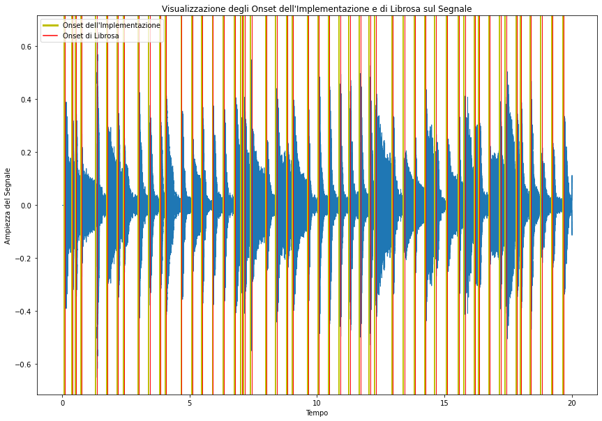

```
	 --- dal notebook: cliccare due volte sull'immagine per ingrandirla e analizzarla nel dettaglio ---
```

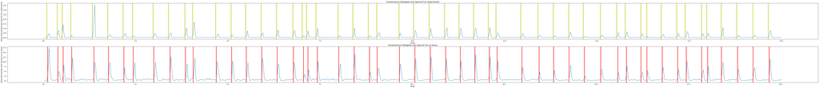

```python
filename = librosa.example('pistachio')
y, sr = librosa.load(filename, duration=DURATION)
study_example(y, sr)
```

```
Numero di Onset di Librosa: 49
Numero di Onset dell'Implementazione: 63
```

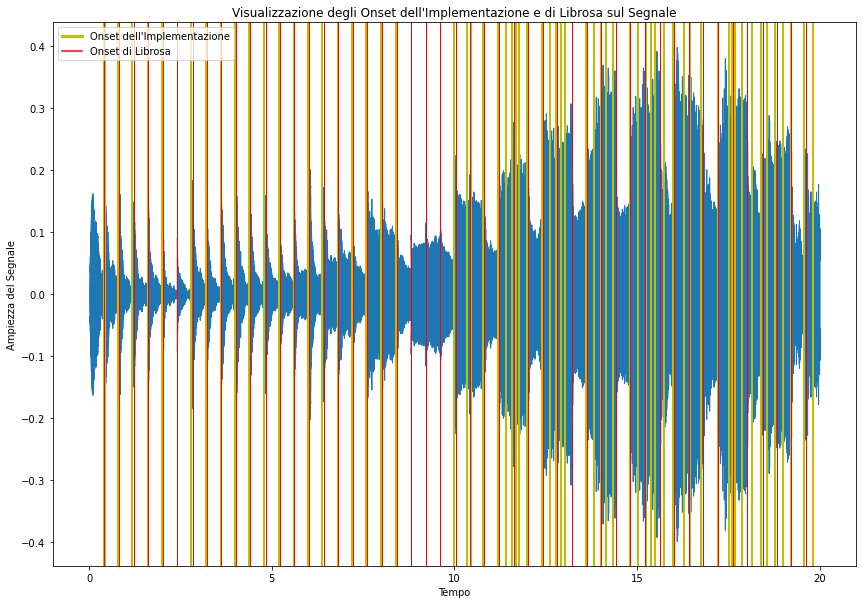

```
	 --- dal notebook: cliccare due volte sull'immagine per ingrandirla e analizzarla nel dettaglio ---
```

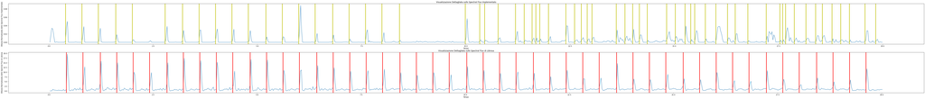

```python
filename = librosa.example('sweetwaltz')
y, sr = librosa.load(filename, duration=DURATION)
study_example(y, sr)
```

Notiamo come, a seconda del metodo utilizzato, cambino sia lo *spectrul flux* (in blu), sia gli onset trovati (in giallo ed in rosso); la curva descritta dall'implementazione ha picchi piu' bassi ed è molto piu' piatta per le basse intensità; nonostante cio' la rilevazione degli onset sembra buona in entrambi i casi.

### La Traccia Peggiore nel Confronto con Librosa: *humpback*

```
Numero di Onset di Librosa: 3
Numero di Onset dell'Implementazione: 26
```

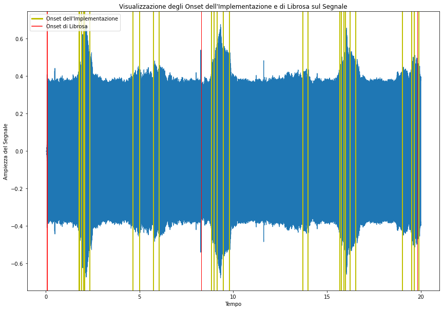

```
	 --- dal notebook: cliccare due volte sull'immagine per ingrandirla e analizzarla nel dettaglio ---
```

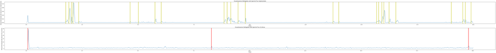

```python
filename = librosa.example('humpback')
y, sr = librosa.load(filename, duration=DURATION)
study_example(y, sr)
```

In questo caso notiamo sorprentemente che lo spectrul flux di librosa sembra essere molto piatto. Probabilmente l'implementazione della libreria soffre segnali così tanto rumorosi, mentre l'implementazione si adatta meglio.

Una criticità dell'implementazione è visibile per il primo picco, non considerato dalla funzione di peak-peaking poiché l'intervallo di tempo in questione avrebbe considerato dei frame temporali negativi.

## Fonti

- Pubblicazione Scientifica: *evaluating the online capabilities of onset detection methods*, Sebastian Bock, Florian Krebs and Markus Schedl: https://ismir2012.ismir.net/event/papers/049_ISMIR_2012.pdf
- *Librosa*, in particolare il codice sorgente delle funzioni:
  - librosa.onset.onset_detect: https://librosa.org/doc/main/generated/librosa.onset.onset_detect.html,
  - librosa.onset.onset_strength: https://librosa.org/doc/main/generated/librosa.onset.onset_strength.html,
  - librosa.util.peak_pick: https://librosa.org/doc/main/generated/librosa.util.peak_pick.html.